# Домашняя работа №5, Плеханов Антон

## Пример оценки максимального правдоподобия для выборки из распределения Пуассона с параметром lambda = 6.

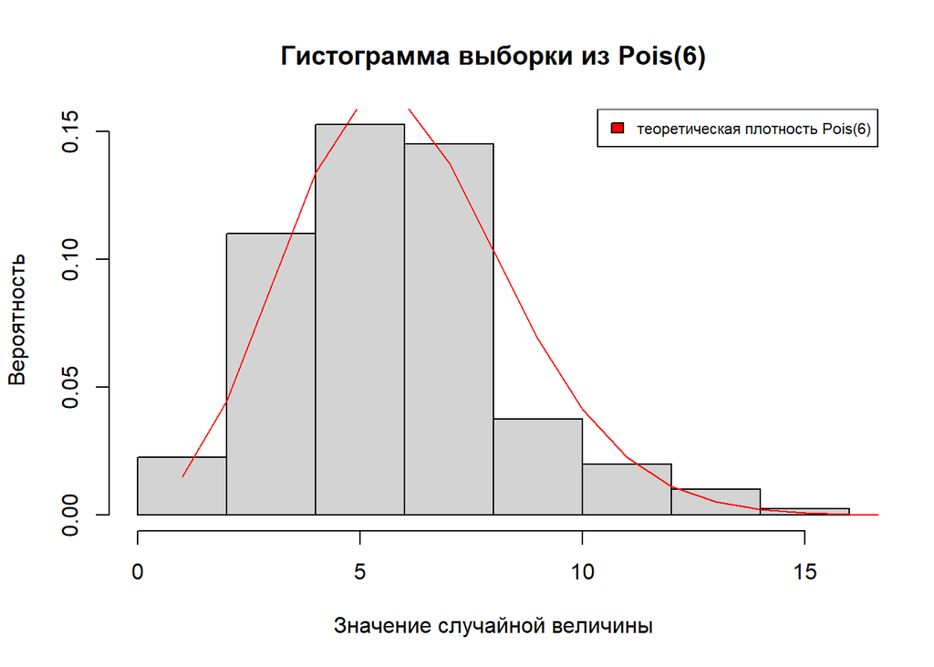

```r
X <- rpois(n = 200, lambda = 6)
hist(X, freq = FALSE, main = "Гистограмма выборки из Pois(6)", ylab = "Вероятность", xlab = "Значение случайной величины")
lines(dpois(1:20, lambda = 6), col = "red")
legend(x = "topright", legend = c("теоретическая плотность Pois(6)"), col = "red", fill = "red", cex = 0.7)
```

Оценим параметр lambda с помощью метода максимального правдоподобия:

```r
pois_neg_log_likelyhood <- function(lambda) {
  n <- length(X)
  return(n * lambda - log(lambda) * sum(X) + sum(log((sapply(X, factorial)))))
}

stats4::mle(pois_neg_log_likelyhood, method = "BFGS", start = 1)
```

```
##
## Call:
## stats4::mle(minuslogl = pois_neg_log_likelyhood, start = 1, method = "BFGS")
##
## Coefficients:
## lambda
##  6.175
```

Результат: MLE достаточна близка к реальному значению параметра lambda.

## Анализ малых и средних выборок из нормального распределения с помощью графикой эмпирический функций распределения, квантилей, метода огибающих

Генерируем по две выборки из нормального распределения малого и умеренного объема:

```r
set.seed(111)
small_sample1 <- rnorm(100, mean = 12, sd = 10)

set.seed(111)
mid_sample1 <- rnorm(1000, mean = 12, sd = 10)
```

Функция norm_empiric_theor_df_plot рисует графики эмпирической функции распределения и теоретической функции нормального распределения с параметрами mean, sd:

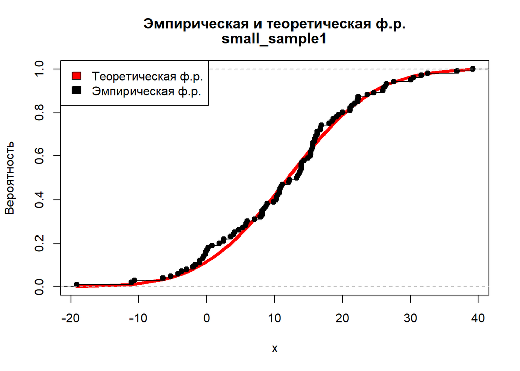

```r
norm_empiric_theor_df_plot <- function(X, mean, sd, main = "") {
  X <- sort(X)

  plot(X, pnorm(X, mean = mean, sd = sd), col = "red", type = "l",
       xlab = "x", ylab = "Вероятность", lwd = 4,
       main = c("Эмпирическая и теоретическая ф.р.", main))
  plot(ecdf(X), add = TRUE)
  legend(x = "topleft", col = c("red", "black"), fill = c("red", "black"),
         legend = c("Теоретическая ф.р.", "Эмпирическая ф.р."))

}

norm_empiric_theor_df_plot(small_sample1,
                           mean = 12, sd = 10,
                           main = "small_sample1")
```

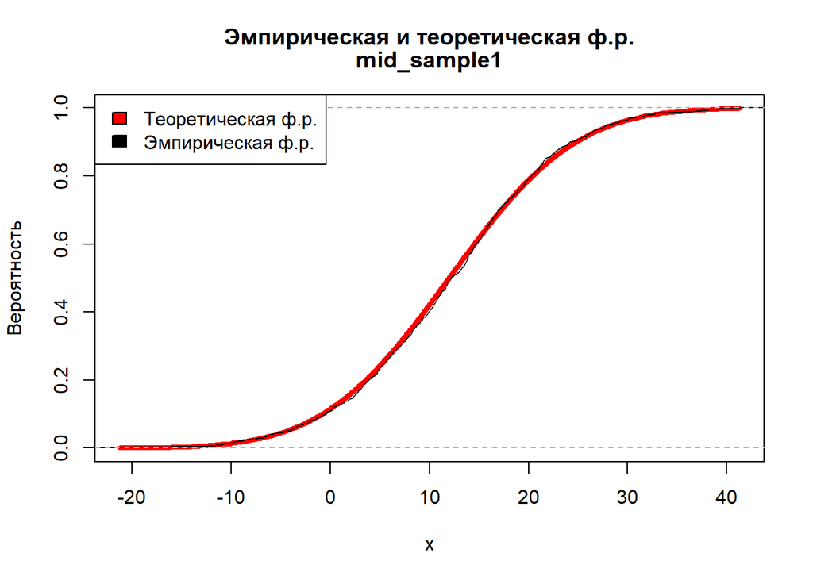

```r
norm_empiric_theor_df_plot(mid_sample1,
                           mean = 12, sd = 10,
                           main = "mid_sample1")
```

Функция рисования квантиль-квантильного графика для выборок из нормального распределения

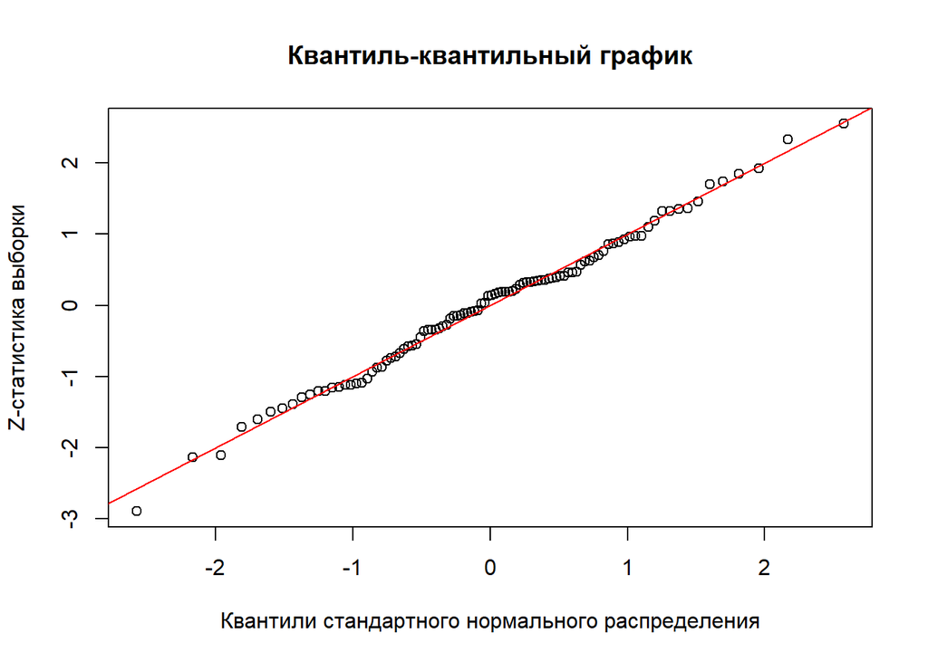

```r
qq_norm_plot <- function(X) {
  # стандартизируем выборку
  z <- (X - mean(X)) / sd(X)

  # рисуем график
  qqnorm(z, main = "Квантиль-квантильный график",
         xlab = "Квантили стандартного нормального распределения",
         ylab = "Z-статистика выборки")

  # добавляем биссектрису
  # (т.е. как должен в идеале выглядеть график Z-статистики)
  lines(c(min(z) - 1, max(z) + 1), c(min(z) - 1, max(z) + 1), col = "red")
}

qq_norm_plot(small_sample1)
```

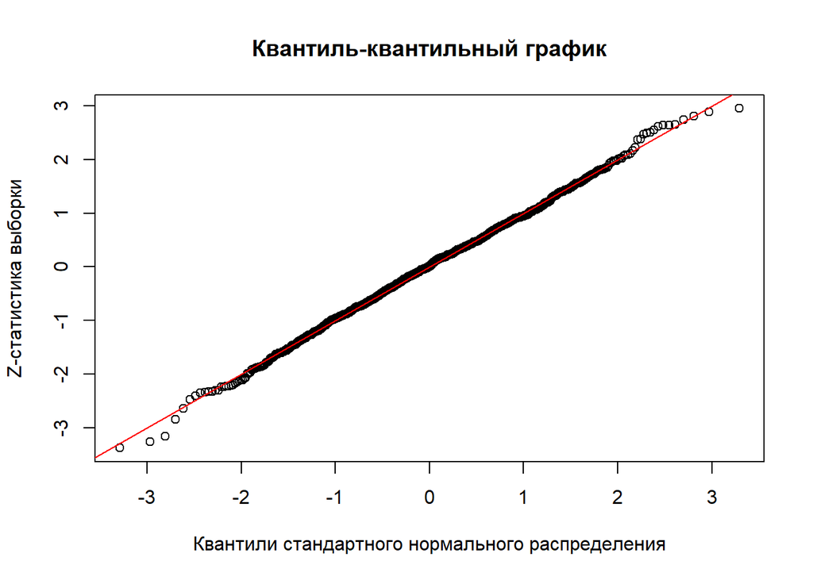

```r
qq_norm_plot(mid_sample1)
```

Анализ выборки методом огибающих. Суть метода: пусть у нас есть некоторая выборка и предположение о том, из какого она распределения. С помощью bootstrap процедуры можем сгенерировать R-ое количество выборок из предполагаемоего распределения, а затем отобразить исходную выборку и bootstrap-выборки на квантиль-квантильном графике. Для bootstrap-выборок можем задать “доверительный интервал” - область, в которой с определенной уверенностью находится выборка из предполагаемого распрделения. Если исходная выборка попадает туда, то гипотезу о принадлежности выборке этому распределению можно считать выполненной, иначе - нет.

Сгенерируем 1000 подвыборок из выборки small_sample1 методом bootstrap:

```r
library(boot)

# хотим проверить, является ли выборка нормально распределенной
x <- small_sample1

# стандартизируем выборку
# Если x из нормального распределения, то z ~ N(0, 1)
z <- sort((x - mean(x)) / sd(x))

# Методом bootstrap генерируем R выборок из N(0, 1)
# одновременно сортируем каждую выборку для отображения на графике
z_boot <- boot(z, sort, R = 1000, sim = "parametric",
               ran.gen = function(data, mle) rnorm(length(data)))
```

Нарисуем квантиль-квантильные графики для всех подвыборок, чтобы воспользоваться методом огибающих:

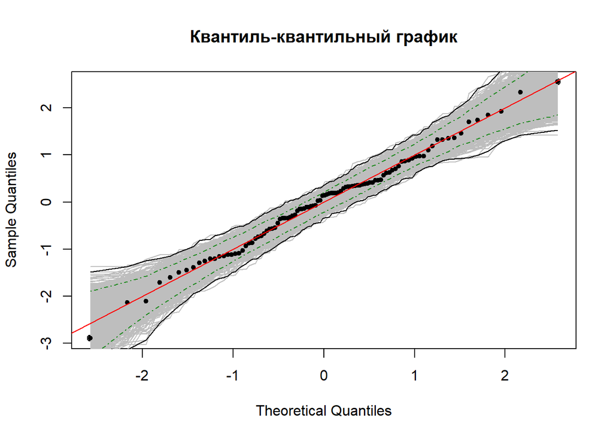

```r
z_qq <- qqnorm(z, main = "Квантиль-квантильный график")
empty <- sapply(1:1000, function(i) lines(qqnorm(z_boot$t[i, ], plot.it = FALSE), col = "grey"))
points(z_qq$x, z_qq$y, pch = 20)
lines(c(min(z) - 1, max(z) + 1), c(min(z) - 1, max(z) + 1), col = "red")

z.env <- envelope(z_boot, level = 0.9)
lines(z_qq$x, z.env$point[1, ], lty = 4, col = "forestgreen")
lines(z_qq$x, z.env$point[2, ], lty = 4, col = "forestgreen")
lines(z_qq$x, z.env$overall[1, ], lty = 1)
lines(z_qq$x, z.env$overall[2, ], lty = 1)
```

## Проверка гипотез о нормальности

Критерий Смирнова-Колмогорова Реализация ks.test() в R позволяет проверять следующие гипотезы: 1) выборка х из распределения y (Нулевая гипотеза - х не из у) 2) выборка х и выборка y из одного распределения (нулевая гипотеза - х и у не из одного распределения)

```r
X <- small_sample1
ks.test(X, "pnorm", 12, 10, alternative = "two.sided")
```

```
##
##  One-sample Kolmogorov-Smirnov test
##
## data:  X
## D = 0.060148, p-value = 0.8623
## alternative hypothesis: two-sided
```

Тест Шапиро-Уилка:

```r
X <- small_sample1
shapiro.test(X)
```

```
##
##  Shapiro-Wilk normality test
##
## data:  X
## W = 0.99343, p-value = 0.9125
```

Тест Андерсона-Дарлинга:

```r
library(nortest)
X <- small_sample1
ad.test(X)
```

```
##
##  Anderson-Darling normality test
##
## data:  X
## A = 0.30553, p-value = 0.5611
```

Тест Крамера фон Мизеса:

```r
X <- small_sample1
cvm.test(X)
```

```
##
##  Cramer-von Mises normality test
##
## data:  X
## W = 0.057928, p-value = 0.3994
```

Тест Колмогорова-Смирнова в модификации Лиллиефорса

```r
X <- small_sample1
lillie.test(X)
```

```
##
##  Lilliefors (Kolmogorov-Smirnov) normality test
##
## data:  X
## D = 0.060432, p-value = 0.4931
```

```r
X <- small_sample1
sf.test(X)
```

```
##
##  Shapiro-Francia normality test
##
## data:  X
## W = 0.99233, p-value = 0.7616
```

Все тесты не противоречат гипотезе о нормальности выборки small_sample1.

## Анализ датасета с помощью вышеупомянутых методов

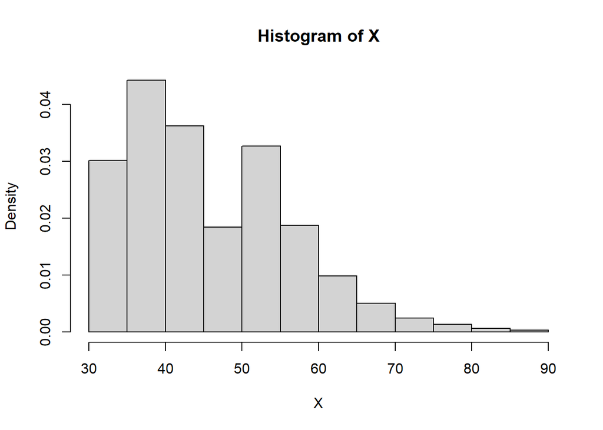

```r
data <- read.csv("C:\\Users\\antpl_0n4duwv\\Documents\\Studies\\prac\\moscow_apartment_listings.csv")

# в качестве выборки возьмем признак footage
X <- data$footage

set.seed(1234)
X <- sample(X)

# гистограмма распрделения X
hist(X, freq = FALSE)
```

ЦПТ гласит, что центрированная и нормированная сумма н.о.р.с.в. сходится к нормальному распределению. Необходимо получить выборку из таких сумм.

Посчитаем значения среднего и дисперсии по всей выборке Х:

```r
X_mean <- mean(X)
X_sd <- sd(X)
```

Функия центрирования и нормирования суммы случайных величин:

```r
centrelize_normalize_sum <- function(Y, mean_val, sd_val) {

  n <- length(Y)
  (sum(Y) - n * mean_val) / (sd_val * sqrt(n))
}
```

```r
make_subsamples <- function(X, k) {
  subsamples <- list()
  index <- 1
  n <- length(X)
  while (index <= n) {
    subsamples <- append(subsamples, list(X[index : min(index + k - 1, n)]))
    index <- index + k
  }
  return(subsamples)
}
```

Разбиваем выборку Х на подвыборки длины 200, затем применяем функцию centrelize_normalize_sum для каждой подвыборки. Таким образом, получим выборку из распределения, стремящегося к нормальному, согласно ЦПТ.

```r
subsamples <- make_subsamples(X, 200)

Y <- mapply(centrelize_normalize_sum, subsamples, rep(X_mean, length(subsamples)), rep(X_sd, length(subsamples)))
```

Получили следущее распределение:

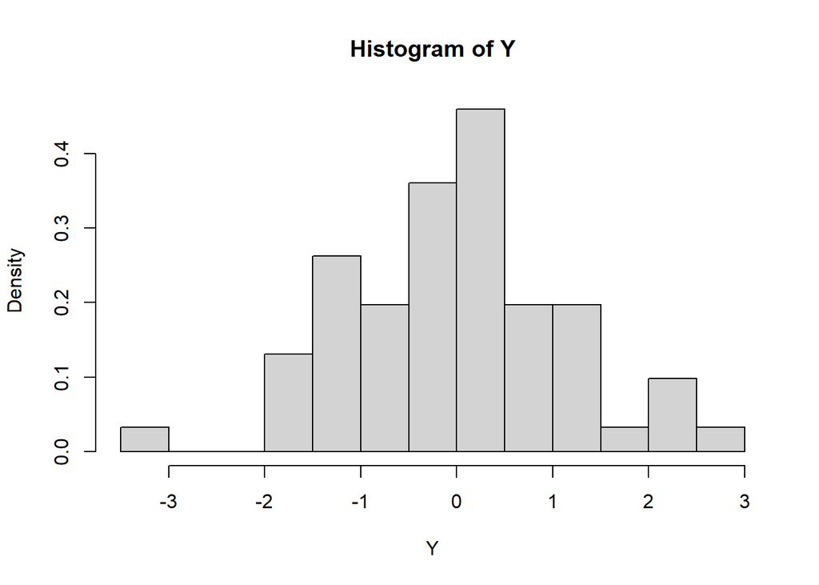

```r
hist(Y, freq = FALSE, breaks = 10)
```

Исходя из гистограммы, можно сделать вывод, что данные можно моделировать с помощью нормального распределения.

Для нормального распределения известны теоретические оценки максимального правдоподобия - выборочные мат.ожидание и дисперсия.

Проверим нормальность распределения с помощью шести критериев нормальности.

Критерий Смирнова-Колмогорова

```r
ks.test(Y, "pnorm", mean(Y), sd(Y), alternative = "two.sided")
```

```
##
##  One-sample Kolmogorov-Smirnov test
##
## data:  Y
## D = 0.073512, p-value = 0.8724
## alternative hypothesis: two-sided
```

p-value > 0.05, => принимается альтернативная гипотеза о том, что выборка из стандартного нормального распределения c параметрами mean(Y), sd(Y).

Тест Шапиро-Уилка:

```r
shapiro.test(Y)
```

```
##
##  Shapiro-Wilk normality test
##
## data:  Y
## W = 0.98442, p-value = 0.6295
```

Считаем гипотезу о нормальности выполненной.

Тест Андерсона-Дарлинга:

```r
ad.test(Y)
```

```
##
##  Anderson-Darling normality test
##
## data:  Y
## A = 0.34693, p-value = 0.4694
```

Гипотеза о нормальности выполнена.

Тест Крамера фон Мизеса:

```r
cvm.test(Y)
```

```
##
##  Cramer-von Mises normality test
##
## data:  Y
## W = 0.052658, p-value = 0.4667
```

Гипотеза о нормальности выполнена.

Тест Колмогорова-Смирнова в модификации Лиллиефорса

```r
lillie.test(Y)
```

```
##
##  Lilliefors (Kolmogorov-Smirnov) normality test
##
## data:  Y
## D = 0.073512, p-value = 0.5684
```

Гипотеза о нормальности выполнена.

Тест Шапиро-Франсия

```r
sf.test(Y)
```

```
##
##  Shapiro-Francia normality test
##
## data:  Y
## W = 0.98111, p-value = 0.3936
```

Гипотеза о нормальности выполнена.

Стандартизируем выборку Y и проведем анализ ее распределения с помощью графиков эмпирической и теоретической функций распределений, а также квантиль-квантильного графика (предполагаемая ф.р. - N(mean(Y), sd(Y))):

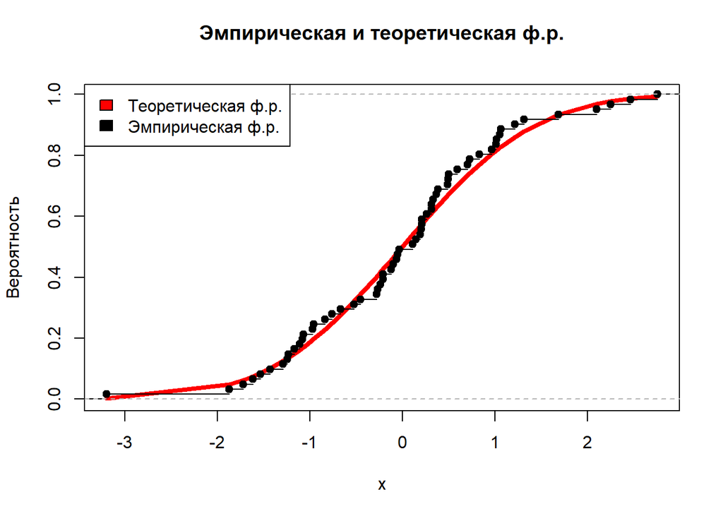

```r
norm_empiric_theor_df_plot(Y, mean(Y), sd(Y))
```

Графики эмпирической и теоретической функции распределения довольно близки, можно сделать вывод в пользу нормальности распределения выборки.

Для построения квантиль-квантильного графика дополнительно стандартизируем выборку:

```r
Z <- (Y - mean(Y)) / sd(Y)
```

Анализ выборки методом огибающих:

[figure not shown]

```r
# Методом bootstrap генерируем R выборок из N(0, 1)
# одновременно сортируем каждую выборку для отображения на графике
z_boot <- boot(z, sort, R = 1000, sim = "parametric",
               ran.gen = function(data, mle) rnorm(length(data)))

z_qq <- qqnorm(z,
               main = c("Квантиль-квантильный график", "для выборки Y"),
               xlab = "Теоретические квантили",
               ylab = "Выборочные квантили")
empty <- sapply(1:1000, function(i) lines(qqnorm(z_boot$t[i, ], plot.it = FALSE), col = "grey"))
points(z_qq$x, z_qq$y, pch = 20)
lines(c(min(z) - 1, max(z) + 1), c(min(z) - 1, max(z) + 1), col = "red")

z.env <- envelope(z_boot, level = 0.9)
lines(z_qq$x, z.env$point[1, ], lty = 4, col = "forestgreen")
lines(z_qq$x, z.env$point[2, ], lty = 4, col = "forestgreen")

legend(x = "topleft", cex = 0.8,
       legend = c("выборочные квантили", "теоретические квантили", "квантили bootstrap-выборок", "огибающие уровня 0.9"),
       col = c("black", "red", "grey", "forestgreen"),
       fill = c("black", "red", "grey", "forestgreen"))
```

## Анализ гамма-распределения со случайными параметрами

#### Выборка из смешанного гамма-распределения размера 100

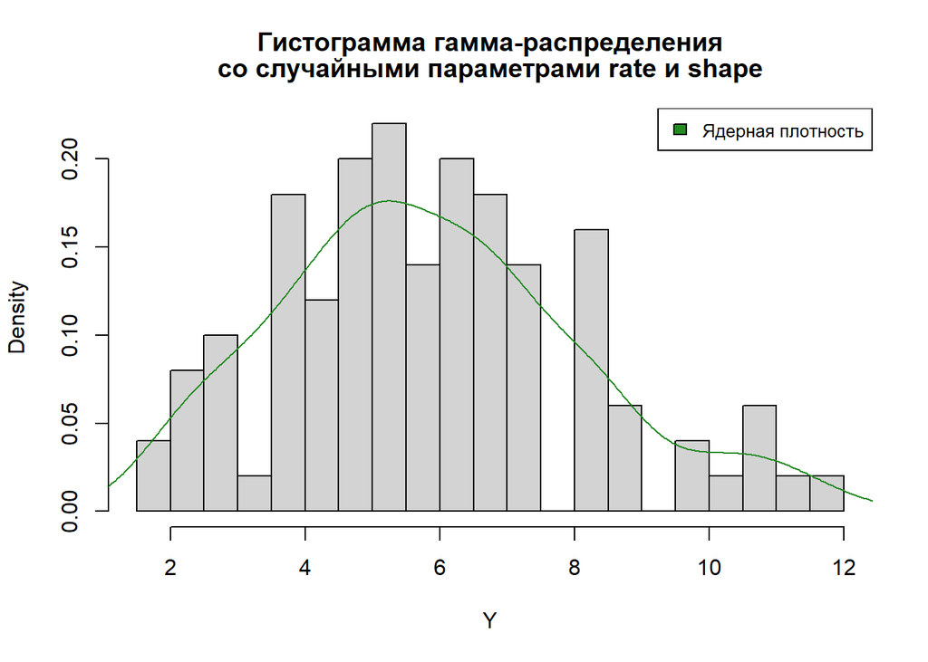

```r
set.seed(1234)
Y <- rgamma(n = 100,
            shape = (6 + runif(100, -1, 1)),
            rate = 1 + 0.1 * rbinom(100, 1, 0.05))

hist(Y, breaks = 20, freq = FALSE, main = c("Гистограмма гамма-распределения", "со случайными параметрами rate и shape"))
lines(density(Y), col = "forestgreen")
legend(x = "topright", legend = c("Ядерная плотность"),
       col = c("forestgreen"), fill = c("forestgreen"),
       cex = 0.8)
```

Для нормального распределения известны теоретические оценки максимального правдоподобия - выборочные мат.ожидание и дисперсия.

Проверим нормальность распределения с помощью шести критериев нормальности:

Тест Смирнова-Колмогорова

```r
ks.test(Y, "pnorm", mean(Y), sd(Y), alternative = "two.sided")
```

```
##
##  One-sample Kolmogorov-Smirnov test
##
## data:  Y
## D = 0.061436, p-value = 0.8447
## alternative hypothesis: two-sided
```

p-value > 0.05, => принимается альтернативная гипотеза о том, что выборка из стандартного нормального распределения c параметрами mean(Y), sd(Y).

Тест Шапиро-Уилка:

```r
shapiro.test(Y)
```

```
##
##  Shapiro-Wilk normality test
##
## data:  Y
## W = 0.97626, p-value = 0.06776
```

p-value > 0.05, следовательно, считаем гипотезу о нормальном распределении выполненной.

Тест Андерсона-Дарлинга:

```r
ad.test(Y)
```

```
##
##  Anderson-Darling normality test
##
## data:  Y
## A = 0.50342, p-value = 0.2002
```

Гипотеза о нормальности выполнена.

Тест Крамера фон Мизеса:

```r
cvm.test(Y)
```

```
##
##  Cramer-von Mises normality test
##
## data:  Y
## W = 0.065017, p-value = 0.3219
```

Гипотеза о нормальности выполнена.

Тест Колмогорова-Смирнова в модификации Лиллиефорса

```r
lillie.test(Y)
```

```
##
##  Lilliefors (Kolmogorov-Smirnov) normality test
##
## data:  Y
## D = 0.061436, p-value = 0.4661
```

Гипотеза о нормальности выполнена.

Тест Шапиро-Франсия

```r
sf.test(Y)
```

```
##
##  Shapiro-Francia normality test
##
## data:  Y
## W = 0.97961, p-value = 0.1108
```

Гипотеза о нормальности выполнена.

Стандартизируем выборку Y и проведем анализ ее распределения с помощью графиков эмпирической и теоретической функций распределений, а также квантиль-квантильного графика (предполагаемая ф.р. - N(mean(Y), sd(Y))):

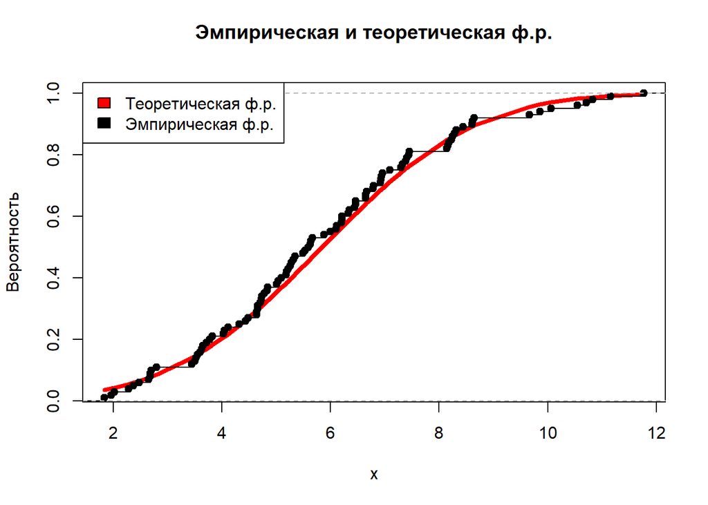

```r
norm_empiric_theor_df_plot(Y, mean(Y), sd(Y))
```

Для построения квантиль-квантильного графика дополнительно стандартизируем выборку:

```r
Z <- (Y - mean(Y)) / sd(Y)
```

Анализ выборки методом огибающих:

[figure not shown]

```r
# Методом bootstrap генерируем R выборок из N(0, 1)
# одновременно сортируем каждую выборку для отображения на графике
z_boot <- boot(z, sort, R = 1000, sim = "parametric",
               ran.gen = function(data, mle) rnorm(length(data)))

z_qq <- qqnorm(z,
               main = c("Квантиль-квантильный график", "для выборки из смешанного гамма-распределения"),
               xlab = "Теоретические квантили",
               ylab = "Выборочные квантили")
empty <- sapply(1:1000, function(i) lines(qqnorm(z_boot$t[i, ], plot.it = FALSE), col = "grey"))
points(z_qq$x, z_qq$y, pch = 20)
lines(c(min(z) - 1, max(z) + 1), c(min(z) - 1, max(z) + 1), col = "red")

z.env <- envelope(z_boot, level = 0.9)
lines(z_qq$x, z.env$point[1, ], lty = 4, col = "forestgreen")
lines(z_qq$x, z.env$point[2, ], lty = 4, col = "forestgreen")

legend(x = "topleft", cex = 0.8,
       legend = c("выборочные квантили", "теоретические квантили", "квантили bootstrap-выборок", "огибающие уровня 0.9"),
       col = c("black", "red", "grey", "forestgreen"),
       fill = c("black", "red", "grey", "forestgreen"))
```

#### Выборка из смешанного гамма-распределения размера 1000

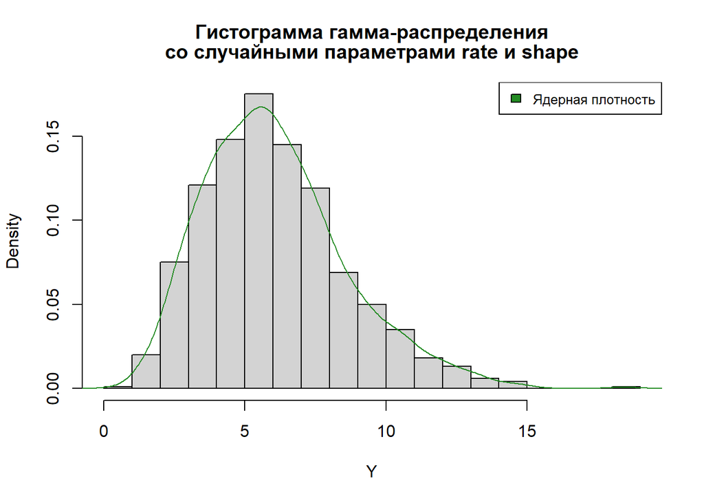

```r
set.seed(1234)
Y <- rgamma(n = 1000,
            shape = (6 + runif(1000, -1, 1)),
            rate = 1 + 0.1 * rbinom(1000, 1, 0.05))

hist(Y, breaks = 20, freq = FALSE, main = c("Гистограмма гамма-распределения", "со случайными параметрами rate и shape"))
lines(density(Y), col = "forestgreen")
legend(x = "topright", legend = c("Ядерная плотность"),
       col = c("forestgreen"), fill = c("forestgreen"),
       cex = 0.8)
```

Для нормального распределения известны теоретические оценки максимального правдоподобия - выборочные мат.ожидание и дисперсия.

Проверим нормальность распределения с помощью шести критериев нормальности.

Критерий Смирнова-Колмогорова

```r
ks.test(Y, "pnorm", mean(Y), sd(Y), alternative = "two.sided")
```

```
##
##  One-sample Kolmogorov-Smirnov test
##
## data:  Y
## D = 0.055076, p-value = 0.004638
## alternative hypothesis: two-sided
```

p-value < 0.05, следовательно, гипотеза о нормальности считается не выполненной.

Тест Шапиро-Уилка:

```r
shapiro.test(Y)
```

```
##
##  Shapiro-Wilk normality test
##
## data:  Y
## W = 0.96721, p-value = 3.156e-14
```

Гипотеза о нормальности отвергается.

Тест Андерсона-Дарлинга:

```r
ad.test(Y)
```

```
##
##  Anderson-Darling normality test
##
## data:  Y
## A = 7.0048, p-value < 2.2e-16
```

Гипотеза о нормальности отвергается.

Тест Крамера фон Мизеса:

```r
cvm.test(Y)
```

```
##
##  Cramer-von Mises normality test
##
## data:  Y
## W = 1.0565, p-value = 9.768e-10
```

Гипотеза о нормальности отвергается.

Тест Колмогорова-Смирнова в модификации Лиллиефорса

```r
lillie.test(Y)
```

```
##
##  Lilliefors (Kolmogorov-Smirnov) normality test
##
## data:  Y
## D = 0.055076, p-value = 1.493e-07
```

Гипотеза о нормальности отвергается.

Тест Шапиро-Франсия

```r
sf.test(Y)
```

```
##
##  Shapiro-Francia normality test
##
## data:  Y
## W = 0.96703, p-value = 6.477e-13
```

Гипотеза о нормальности отвергается.

Стандартизируем выборку Y и проведем анализ ее распределения с помощью графиков эмпирической и теоретической функций распределений, а также квантиль-квантильного графика (предполагаемая ф.р. - N(mean(Y), sd(Y))):

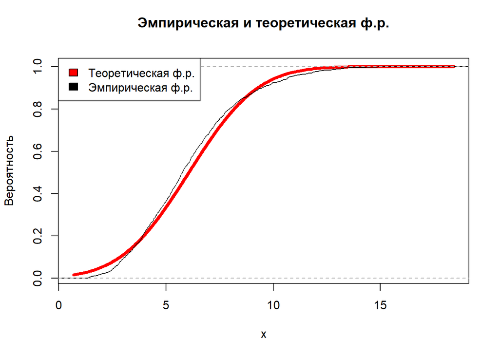

```r
norm_empiric_theor_df_plot(Y, mean(Y), sd(Y))
```

Графики эмпирической и теоретической ф.р. заметно отклоняются друг от друга, график эмпирической ф.р. имеет более резкие выпуклости. Учитывая гистограмму, а также результаты тестов на нормальность, можно сделать вывод, что подобные отклонения между ф.р. для больших выборок являются значительными.

Для построения квантиль-квантильного графика дополнительно стандартизируем выборку:

```r
Z <- (Y - mean(Y)) / sd(Y)
```

Анализ выборки методом огибающих:

[figure not shown]

```r
# Методом bootstrap генерируем R выборок из N(0, 1)
# одновременно сортируем каждую выборку для отображения на графике
z_boot <- boot(z, sort, R = 1000, sim = "parametric",
               ran.gen = function(data, mle) rnorm(length(data)))

z_qq <- qqnorm(z,
               main = c("Квантиль-квантильный график", "для выборки из смешанного гамма-распределения"),
               xlab = "Теоретические квантили",
               ylab = "Выборочные квантили")
empty <- sapply(1:1000, function(i) lines(qqnorm(z_boot$t[i, ], plot.it = FALSE), col = "grey"))
points(z_qq$x, z_qq$y, pch = 20)
lines(c(min(z) - 1, max(z) + 1), c(min(z) - 1, max(z) + 1), col = "red")

z.env <- envelope(z_boot, level = 0.9)
lines(z_qq$x, z.env$point[1, ], lty = 4, col = "forestgreen")
lines(z_qq$x, z.env$point[2, ], lty = 4, col = "forestgreen")

legend(x = "topleft", cex = 0.8,
       legend = c("выборочные квантили", "теоретические квантили", "квантили bootstrap-выборок", "огибающие уровня 0.9"),
       col = c("black", "red", "grey", "forestgreen"),
       fill = c("black", "red", "grey", "forestgreen"))
```